# Trabalho ASN Regressão Linear

Emmanuel, Diego e Edgar

[figure not shown]

## Estimativa de Gordura corporal

A partir de um estudo realizado com 252 indivíduos, coletaram-se diversas amostras com as medidas corporais. A variável Y (Preditora) recebe o nome de “BodyFat” que corresponde ao total de gordura acumulada do indivíduo. Nosso objetivo com este estudo é inferir quais medidas coletadas posteriormente serão suficientes para prever o volume total de gordura do indivíduo para otimizar o trabalho.

#Origem da Base de Dados - http://staff.pubhealth.ku.dk/~tag/Teaching/share/data/Bodyfat.html

### Features:

**Density:** determined from underwater weighing  
**bodyfat:** Percent body fat from Siri’s (1956) equation  
**Age (years):** Idade em anos  
**Weight (lbs):** Peso em libras  
**Height (inches):** Altura em polegadas  
**Neck circumference (cm):** Circunferencia do Pescoço  
**Chest circumference (cm):** Circunferencia do Peito  
**Abdomen 2 circumference (cm):** Circunferencia do Abdomen  
**Hip circumference (cm):** Circunferencia do Quadril  
**Thigh circumference (cm):** Circunferencia da Coxa  
**Knee circumference (cm):** Circunferencia do Joelho  
**Ankle circumference (cm):** Circunferencia do Tornozelo  
**Biceps (extended) circumference (cm):** Circunferencia do Biceps  
**Forearm circumference (cm):** Circunferencia do antebraço  
**Wrist circumference (cm):** Circunferencia do Pulso

### Bibliotecas Utilizadas

```r
library(readr)
library(openxlsx) #biblioteca para escrever arquivo em excel
library(haven)
library(readxl)
library(tidyverse)
library(yardstick) #biblioteca para calcular medidas de erro
library(lmtest) # calcula o teste de homogeneidade de variancia
library(car) # calcula vif
library(ggraph)
library(plotly)
library(ggstance)
library(jtools)
library(olsrr)
library(PerformanceAnalytics)
library(correlation)
library(dplyr)
library(Boruta)
library(nortest)
library(knitr)
```

Banco de dados **Bodyfat.csv**  
(10 primeiros Registros)

| Density | bodyfat | Age | Weight | Height | Neck | Chest | Abdomen | Hip | Thigh | Knee | Ankle | Biceps | Forearm | Wrist |
| --- | --- | --- | --- | --- | --- | --- | --- | --- | --- | --- | --- | --- | --- | --- |
| 1.0708 | 12.3 | 23 | 154.25 | 67.75 | 36.2 | 93.1 | 85.2 | 94.5 | 59.0 | 37.3 | 21.9 | 32.0 | 27.4 | 17.1 |
| 1.0853 | 6.1 | 22 | 173.25 | 72.25 | 38.5 | 93.6 | 83.0 | 98.7 | 58.7 | 37.3 | 23.4 | 30.5 | 28.9 | 18.2 |
| 1.0414 | 25.3 | 22 | 154.00 | 66.25 | 34.0 | 95.8 | 87.9 | 99.2 | 59.6 | 38.9 | 24.0 | 28.8 | 25.2 | 16.6 |
| 1.0751 | 10.4 | 26 | 184.75 | 72.25 | 37.4 | 101.8 | 86.4 | 101.2 | 60.1 | 37.3 | 22.8 | 32.4 | 29.4 | 18.2 |
| 1.0340 | 28.7 | 24 | 184.25 | 71.25 | 34.4 | 97.3 | 100.0 | 101.9 | 63.2 | 42.2 | 24.0 | 32.2 | 27.7 | 17.7 |
| 1.0502 | 20.9 | 24 | 210.25 | 74.75 | 39.0 | 104.5 | 94.4 | 107.8 | 66.0 | 42.0 | 25.6 | 35.7 | 30.6 | 18.8 |
| 1.0549 | 19.2 | 26 | 181.00 | 69.75 | 36.4 | 105.1 | 90.7 | 100.3 | 58.4 | 38.3 | 22.9 | 31.9 | 27.8 | 17.7 |
| 1.0704 | 12.4 | 25 | 176.00 | 72.50 | 37.8 | 99.6 | 88.5 | 97.1 | 60.0 | 39.4 | 23.2 | 30.5 | 29.0 | 18.8 |
| 1.0900 | 4.1 | 25 | 191.00 | 74.00 | 38.1 | 100.9 | 82.5 | 99.9 | 62.9 | 38.3 | 23.8 | 35.9 | 31.1 | 18.2 |
| 1.0722 | 11.7 | 23 | 198.25 | 73.50 | 42.1 | 99.6 | 88.6 | 104.1 | 63.1 | 41.7 | 25.0 | 35.6 | 30.0 | 19.2 |

### Análise Univariada

Os dados disponíveis na variável Density, é utilizado para o calculo da variável bodyfat. Devido a isso, resolvemos entender qual seria a correlação entre elas.

```r
cor(Bodyfat$Density,Bodyfat$bodyfat)
```

```
## [1] -0.9877824
```

Como a correlação entre elas é inversamente alta. E nosso target(y) é bodyfat, iremos eliminar a variável Density do modelo.

```r
Bodyfat <- Bodyfat %>%
  select(-Density)

Bodyfat
```

```
## # A tibble: 252 × 14
##    bodyfat   Age Weight Height  Neck Chest Abdomen   Hip Thigh  Knee Ankle
##      <dbl> <dbl>  <dbl>  <dbl> <dbl> <dbl>   <dbl> <dbl> <dbl> <dbl> <dbl>
##  1    12.3    23   154.   67.8  36.2  93.1    85.2  94.5  59    37.3  21.9
##  2     6.1    22   173.   72.2  38.5  93.6    83    98.7  58.7  37.3  23.4
##  3    25.3    22   154    66.2  34    95.8    87.9  99.2  59.6  38.9  24
##  4    10.4    26   185.   72.2  37.4 102.     86.4 101.   60.1  37.3  22.8
##  5    28.7    24   184.   71.2  34.4  97.3   100   102.   63.2  42.2  24
##  6    20.9    24   210.   74.8  39   104.     94.4 108.   66    42    25.6
##  7    19.2    26   181    69.8  36.4 105.     90.7 100.   58.4  38.3  22.9
##  8    12.4    25   176    72.5  37.8  99.6    88.5  97.1  60    39.4  23.2
##  9     4.1    25   191    74    38.1 101.     82.5  99.9  62.9  38.3  23.8
## 10    11.7    23   198.   73.5  42.1  99.6    88.6 104.   63.1  41.7  25
## # … with 242 more rows, and 3 more variables: Biceps <dbl>, Forearm <dbl>,
## #   Wrist <dbl>
```

#### Variável **Bodyfat**: Target

Identificamos que existem dois registros na target que consideramos inválidos, um com bodyfat igual a 0 e outro com o bodyfat igual a 47.50.

Optamos pela exclusão.

```r
summary(Bodyfat$bodyfat)
```

```
##    Min. 1st Qu.  Median    Mean 3rd Qu.    Max.
##    0.00   12.47   19.20   19.15   25.30   47.50
```

```r
sd(Bodyfat$bodyfat)
```

```
## [1] 8.36874
```

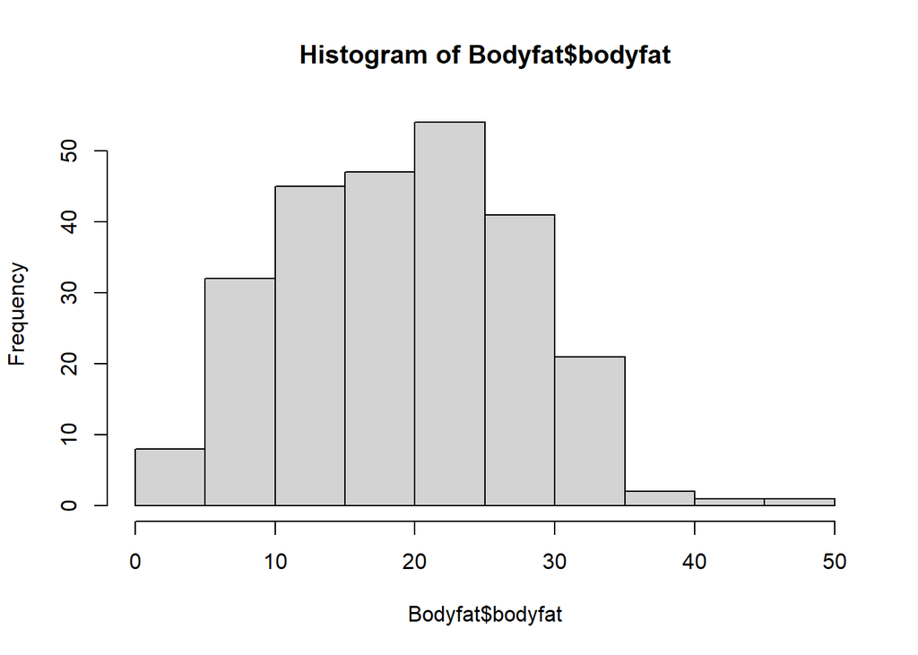

```r
hist(Bodyfat$bodyfat)
```

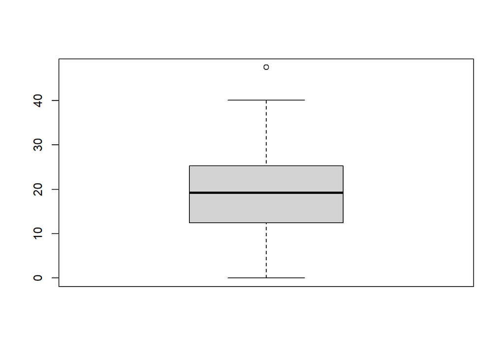

```r
boxplot(Bodyfat$bodyfat)
```

```r
#Analisando os outliers
Bodyfat_bodyfat= Bodyfat[order(Bodyfat$bodyfat),]
#tail(Bodyfat_bodyfat ,4)

Bodyfat <- filter(Bodyfat,bodyfat<47.50 & bodyfat>0)
```

#### Variável **Age**: Idade

```r
summary(Bodyfat$Age)
```

```
##    Min. 1st Qu.  Median    Mean 3rd Qu.    Max.
##   22.00   35.25   43.00   44.88   54.00   81.00
```

```r
sd(Bodyfat$Age)
```

```
## [1] 12.64282
```

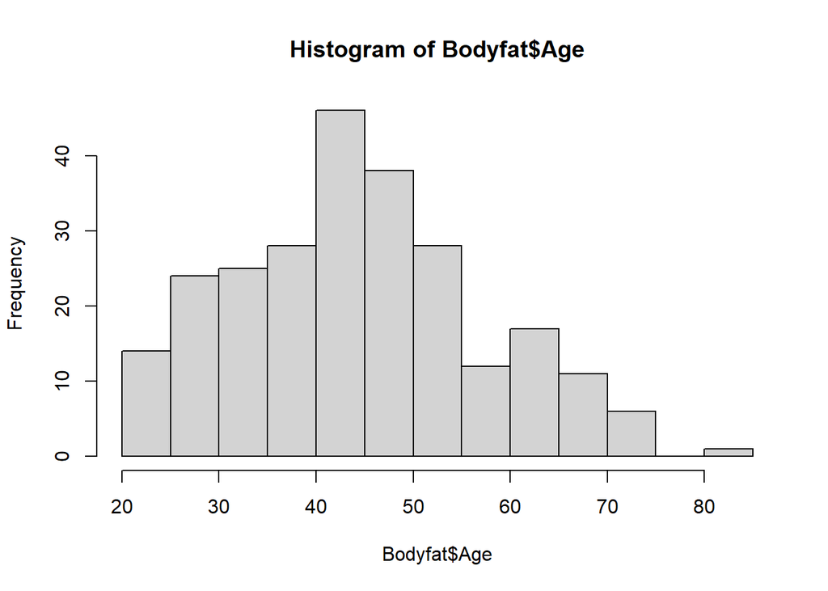

```r
hist(Bodyfat$Age)
```

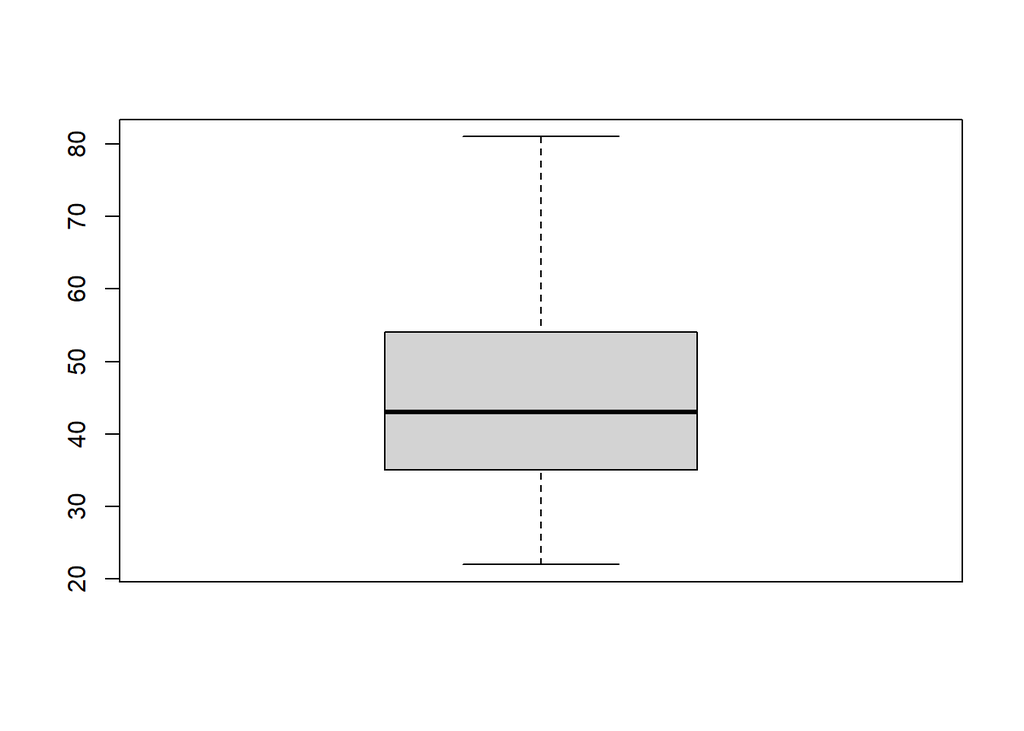

```r
boxplot(Bodyfat$Age)
```

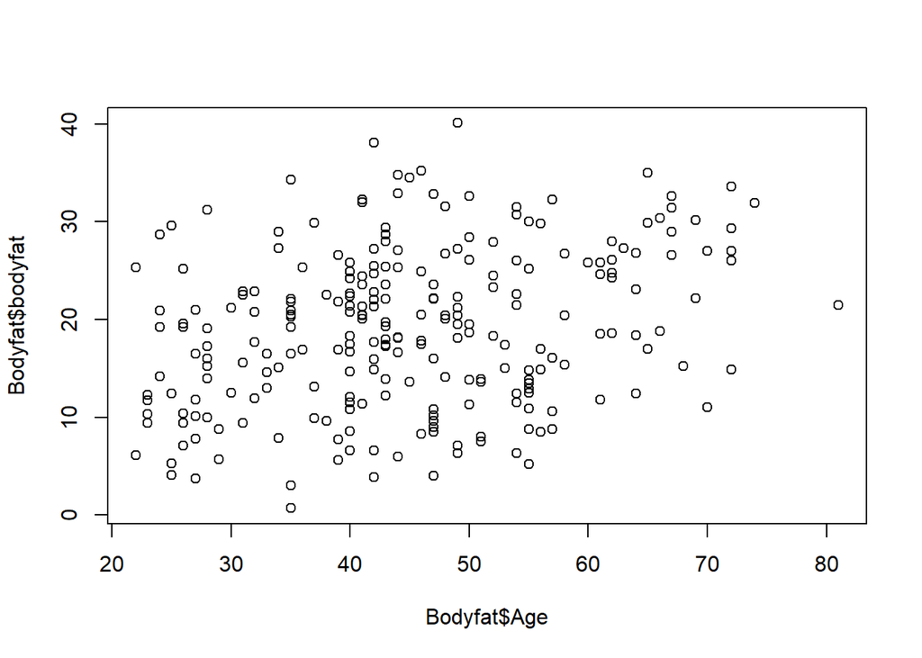

```r
plot(Bodyfat$Age, Bodyfat$bodyfat)
```

```r
#Analisando os outliers
Bodyfat_Age= Bodyfat[order(Bodyfat$Age),]
tail(Bodyfat_Age ,4)
```

```
## # A tibble: 4 × 14
##   bodyfat   Age Weight Height  Neck Chest Abdomen   Hip Thigh  Knee Ankle Biceps
##     <dbl> <dbl>  <dbl>  <dbl> <dbl> <dbl>   <dbl> <dbl> <dbl> <dbl> <dbl>  <dbl>
## 1    29.3    72   187.   66    38.9 111.    112.  102.   60.3  37.3  21.5   31.3
## 2    26      72   191.   70.5  38.9 108.    101.   97.8  56    41.6  22.7   30.5
## 3    31.9    74   208.   70    40.8 112.    108.  107.   59.3  42.2  24.6   33.7
## 4    21.5    81   161.   70.2  37.8  96.4    95.4  99.3  53.5  37.5  21.5   31.4
## # … with 2 more variables: Forearm <dbl>, Wrist <dbl>
```

```r
# Realiza o teste
testeShapiro_Age <- shapiro.test(Bodyfat$Age)

# Exibe teste
testeShapiro_Age
```

```
##
##  Shapiro-Wilk normality test
##
## data:  Bodyfat$Age
## W = 0.9792, p-value = 0.001003
```

```r
reg_simples_Age <- lm(bodyfat ~ Age, data=Bodyfat)
summary(reg_simples_Age)
```

```
##
## Call:
## lm(formula = bodyfat ~ Age, data = Bodyfat)
##
## Residuals:
##     Min      1Q  Median      3Q     Max
## -16.565  -6.152   0.405   5.227  20.215
##
## Coefficients:
##             Estimate Std. Error t value Pr(>|t|)
## (Intercept)  10.7151     1.8183   5.893 1.23e-08 ***
## Age           0.1871     0.0390   4.798 2.77e-06 ***
## ---
## Signif. codes:  0 '***' 0.001 '**' 0.01 '*' 0.05 '.' 0.1 ' ' 1
##
## Residual standard error: 7.781 on 248 degrees of freedom
## Multiple R-squared:  0.08495,    Adjusted R-squared:  0.08126
## F-statistic: 23.02 on 1 and 248 DF,  p-value: 2.765e-06
```

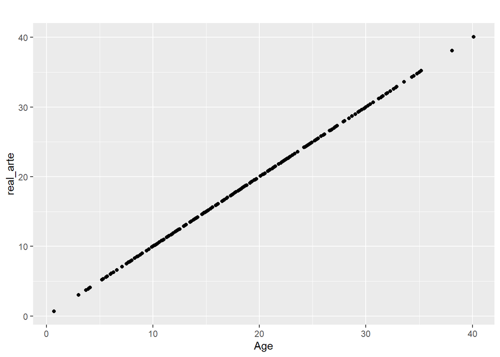

```r
meus_desenhos <- Bodyfat %>% mutate(chute_media_Age = mean(Bodyfat$bodyfat),chute_modelo_Age = reg_simples_Age$fitted.values)

arte <- ggplot()
arte <- arte + geom_point(data=meus_desenhos, aes(x=bodyfat, y=bodyfat), color = "black" ) +
  labs(title = "",
       x = "Age",
       y = "real_arte",
       color = "green")
arte
```

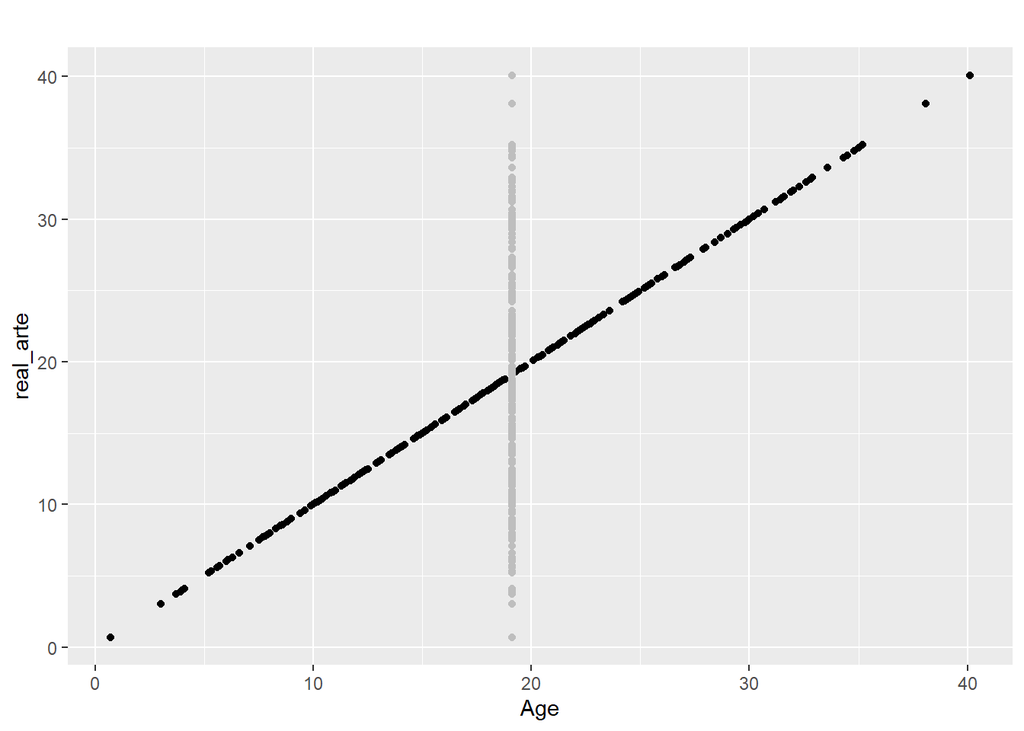

```r
arte <- arte + geom_point(data=meus_desenhos, aes(x=chute_media_Age, y=bodyfat), color = "gray" )
arte
```

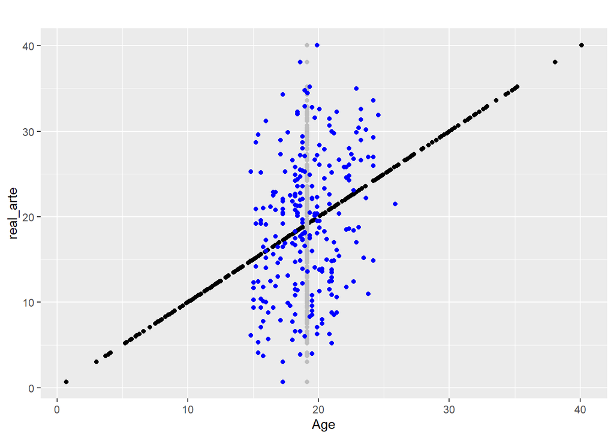

```r
arte <- arte + geom_point(data=meus_desenhos, aes(x=chute_modelo_Age, y=bodyfat), color = "blue" )
arte
```

Análise da variável Weight (Peso)

Optamos por fazer a conversão para Kilos

```r
Bodyfat$Weight = Bodyfat$Weight/2.205

summary(Bodyfat$Weight)
```

```
##    Min. 1st Qu.  Median    Mean 3rd Qu.    Max.
##   56.69   72.22   80.05   81.18   89.31  164.69
```

```r
sd(Bodyfat$Weight)
```

```
## [1] 13.21854
```

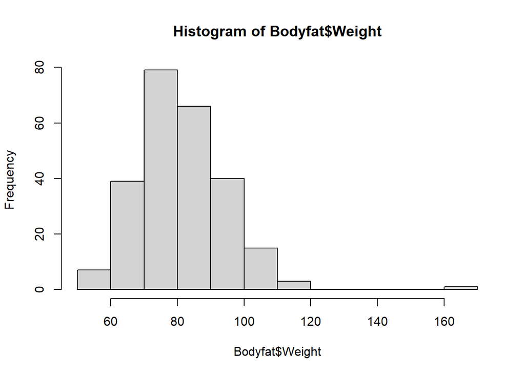

```r
hist(Bodyfat$Weight)
```

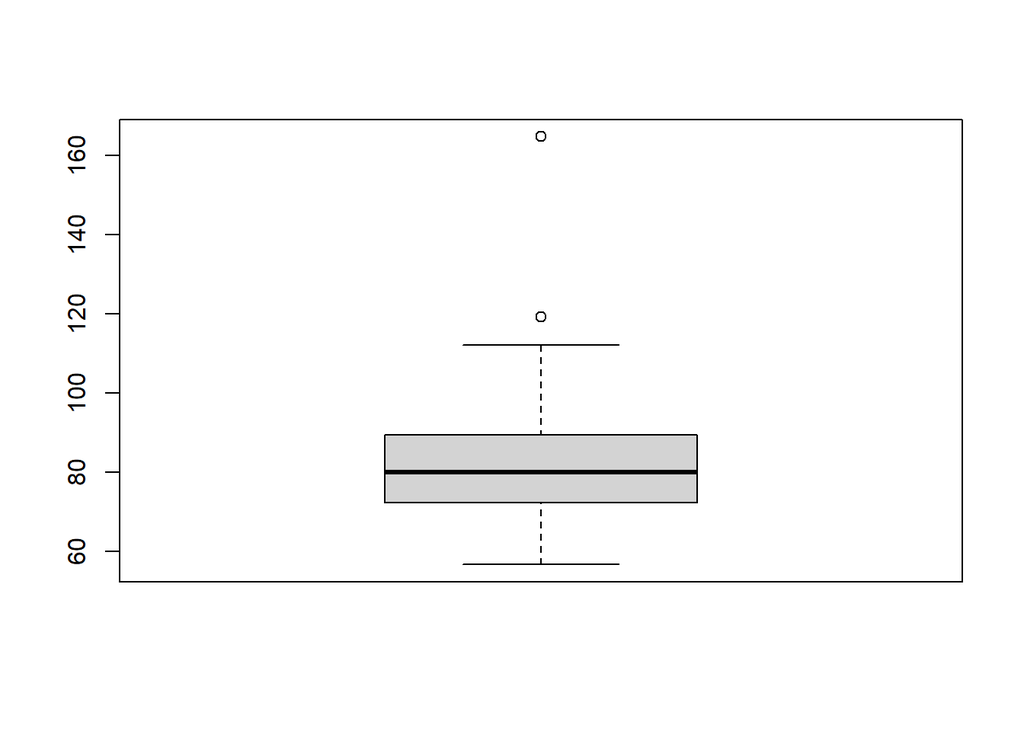

```r
boxplot(Bodyfat$Weight)
```

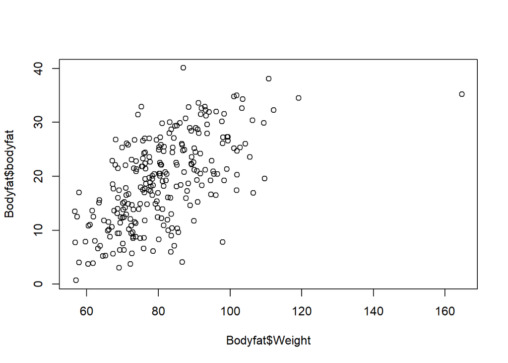

```r
plot(Bodyfat$Weight, Bodyfat$bodyfat)
```

```r
reg_simples_Weight <- lm(bodyfat ~ Weight, data=Bodyfat)
summary(reg_simples_Weight)
```

```
##
## Call:
## lm(formula = bodyfat ~ Weight, data = Bodyfat)
##
## Residuals:
##      Min       1Q   Median       3Q      Max
## -17.5248  -4.5300   0.1087   4.9479  18.8464
##
## Coefficients:
##              Estimate Std. Error t value Pr(>|t|)
## (Intercept) -10.93862    2.55907  -4.274 2.73e-05 ***
## Weight        0.37019    0.03111  11.898  < 2e-16 ***
## ---
## Signif. codes:  0 '***' 0.001 '**' 0.01 '*' 0.05 '.' 0.1 ' ' 1
##
## Residual standard error: 6.49 on 248 degrees of freedom
## Multiple R-squared:  0.3634, Adjusted R-squared:  0.3608
## F-statistic: 141.6 on 1 and 248 DF,  p-value: < 2.2e-16
```

```r
#Analisando os outliers
Bodyfat_Weight= Bodyfat[order(Bodyfat$Weight),]
tail(Bodyfat_Weight ,4)
```

```
## # A tibble: 4 × 14
##   bodyfat   Age Weight Height  Neck Chest Abdomen   Hip Thigh  Knee Ankle Biceps
##     <dbl> <dbl>  <dbl>  <dbl> <dbl> <dbl>   <dbl> <dbl> <dbl> <dbl> <dbl>  <dbl>
## 1    38.1    42   111.   76    41.8  115.    114.  112.  68.5  45    25.5   37.1
## 2    32.3    41   112.   73.5  42.1  117     116.  116.  71.2  43.3  26.3   37.3
## 3    34.5    45   119.   68.8  43.2  128.    126.  126.  72.5  39.6  26.6   36.4
## 4    35.2    46   165.   72.2  51.2  136.    148.  148.  87.3  49.1  29.6   45
## # … with 2 more variables: Forearm <dbl>, Wrist <dbl>
```

```r
# Realiza o teste
testeShapiro_Weight <- shapiro.test(Bodyfat$Weight)

# Exibe teste
testeShapiro_Weight
```

```
##
##  Shapiro-Wilk normality test
##
## data:  Bodyfat$Weight
## W = 0.93703, p-value = 7.297e-09
```

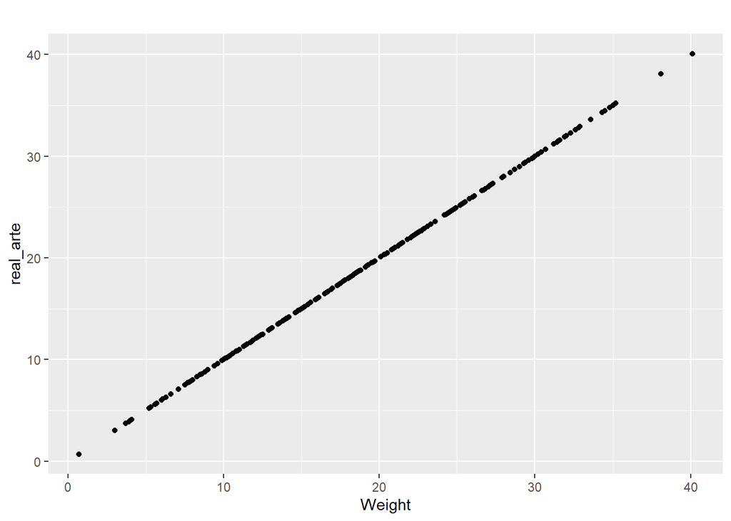

```r
meus_desenhos <- Bodyfat %>% mutate(chute_media_Weight = mean(Bodyfat$bodyfat),chute_modelo_Weight = reg_simples_Weight$fitted.values)

arte <- ggplot()
arte <- arte + geom_point(data=meus_desenhos, aes(x=bodyfat, y=bodyfat), color = "black" ) +
  labs(title = "",
       x = "Weight",
       y = "real_arte",
       color = "green")
arte
```

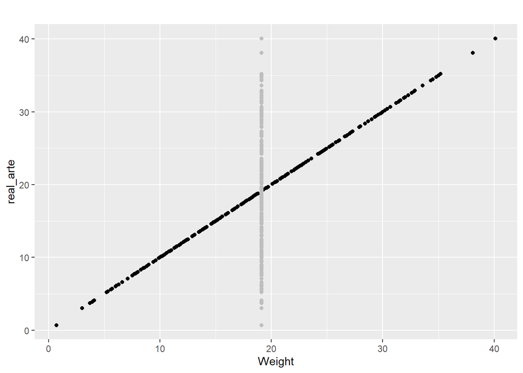

```r
arte <- arte + geom_point(data=meus_desenhos, aes(x=chute_media_Weight, y=bodyfat), color = "gray" )
arte
```

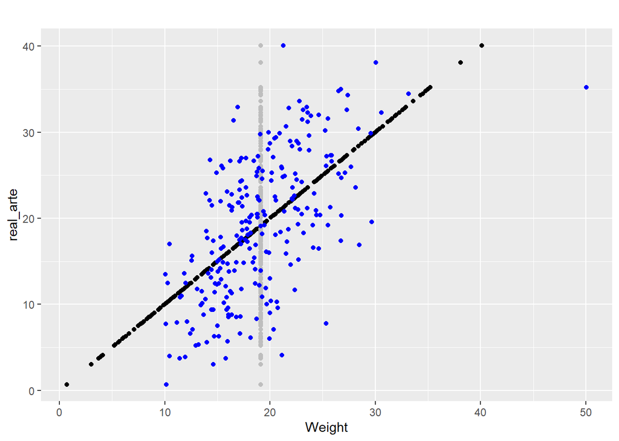

```r
arte <- arte + geom_point(data=meus_desenhos, aes(x=chute_modelo_Weight, y=bodyfat), color = "blue" )
arte
```

Análise da variável Height

Optamos por converter para metros

```r
Bodyfat$Height = Bodyfat$Height*2.5 # Convert to cm
Bodyfat$Height = Bodyfat$Height/100 # Convert to metros

summary(Bodyfat$Height)
```

```
##    Min. 1st Qu.  Median    Mean 3rd Qu.    Max.
##  0.7375  1.7078  1.7531  1.7546  1.8062  1.9438
```

```r
sd(Bodyfat$Height)
```

```
## [1] 0.09135366
```

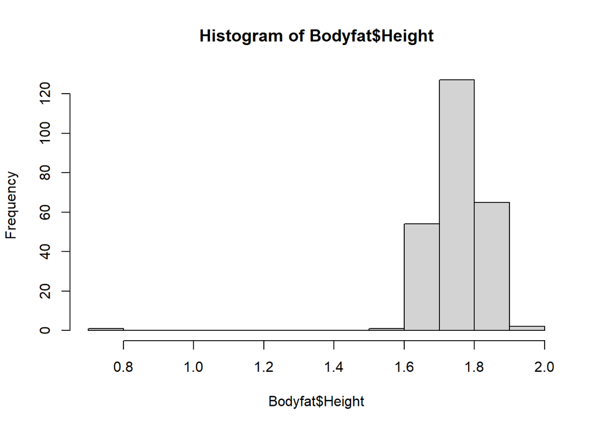

```r
hist(Bodyfat$Height)
```

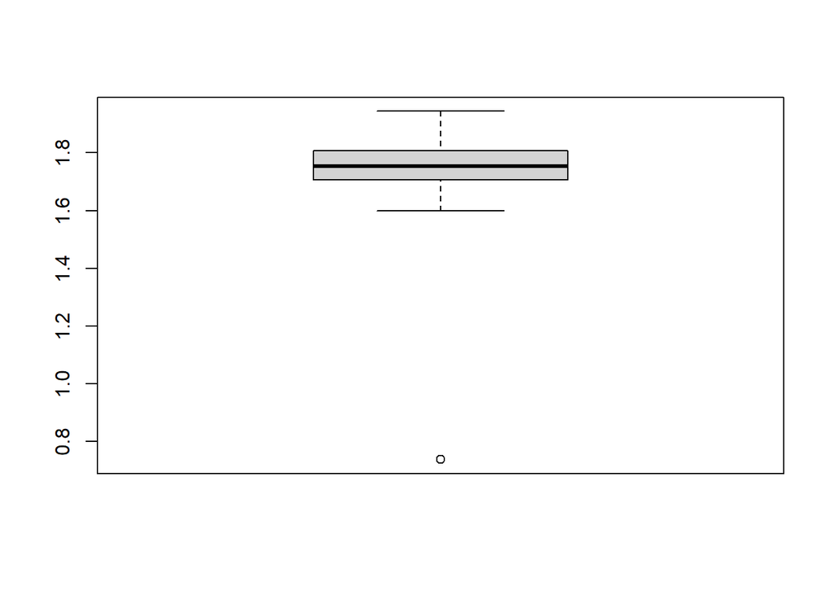

```r
boxplot(Bodyfat$Height)
```

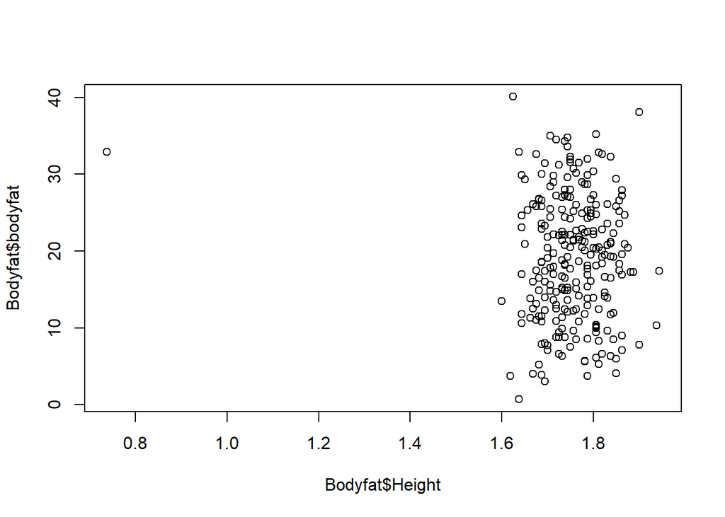

```r
plot(Bodyfat$Height, Bodyfat$bodyfat)
```

```r
reg_simples_Height <- lm(bodyfat ~ Height, data=Bodyfat)
summary(reg_simples_Height)
```

```
##
## Call:
## lm(formula = bodyfat ~ Height, data = Bodyfat)
##
## Residuals:
##     Min      1Q  Median      3Q     Max
## -19.196  -6.639   0.410   6.122  20.121
##
## Coefficients:
##             Estimate Std. Error t value Pr(>|t|)
## (Intercept)   30.832      9.886   3.119  0.00203 **
## Height        -6.678      5.627  -1.187  0.23640
## ---
## Signif. codes:  0 '***' 0.001 '**' 0.01 '*' 0.05 '.' 0.1 ' ' 1
##
## Residual standard error: 8.111 on 248 degrees of freedom
## Multiple R-squared:  0.005648,   Adjusted R-squared:  0.001639
## F-statistic: 1.409 on 1 and 248 DF,  p-value: 0.2364
```

```r
#Analisando os outliers
Bodyfat_Height= Bodyfat[order(Bodyfat$Height),]
tail(Bodyfat_Height ,4)
```

```
## # A tibble: 4 × 14
##   bodyfat   Age Weight Height  Neck Chest Abdomen   Hip Thigh  Knee Ankle Biceps
##     <dbl> <dbl>  <dbl>  <dbl> <dbl> <dbl>   <dbl> <dbl> <dbl> <dbl> <dbl>  <dbl>
## 1     7.8    27   98.0   1.9   39.4 104.     90.9  108.  66.2  39.2  25.9   37.2
## 2    38.1    42  111.    1.9   41.8 115.    114.   112.  68.5  45    25.5   37.1
## 3    10.3    23   85.3   1.94  38    96.6    85.3  102.  59.1  37.6  23.2   31.8
## 4    17.4    53  102.    1.94  41.1 113.     99.2  108.  61.7  42.3  23.2   32.9
## # … with 2 more variables: Forearm <dbl>, Wrist <dbl>
```

```r
# Realiza o teste
testeShapiro_Height <- shapiro.test(Bodyfat$Height)

# Exibe teste
testeShapiro_Height
```

```
##
##  Shapiro-Wilk normality test
##
## data:  Bodyfat$Height
## W = 0.68534, p-value < 2.2e-16
```

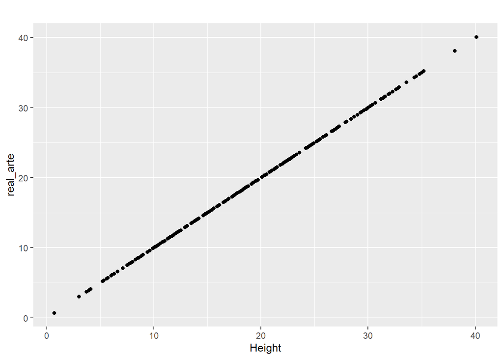

```r
meus_desenhos <- Bodyfat %>% mutate(chute_media_Height = mean(Bodyfat$bodyfat),chute_modelo_Height = reg_simples_Height$fitted.values)

arte <- ggplot()
arte <- arte + geom_point(data=meus_desenhos, aes(x=bodyfat, y=bodyfat), color = "black" ) +
  labs(title = "",
       x = "Height",
       y = "real_arte",
       color = "green")
arte
```

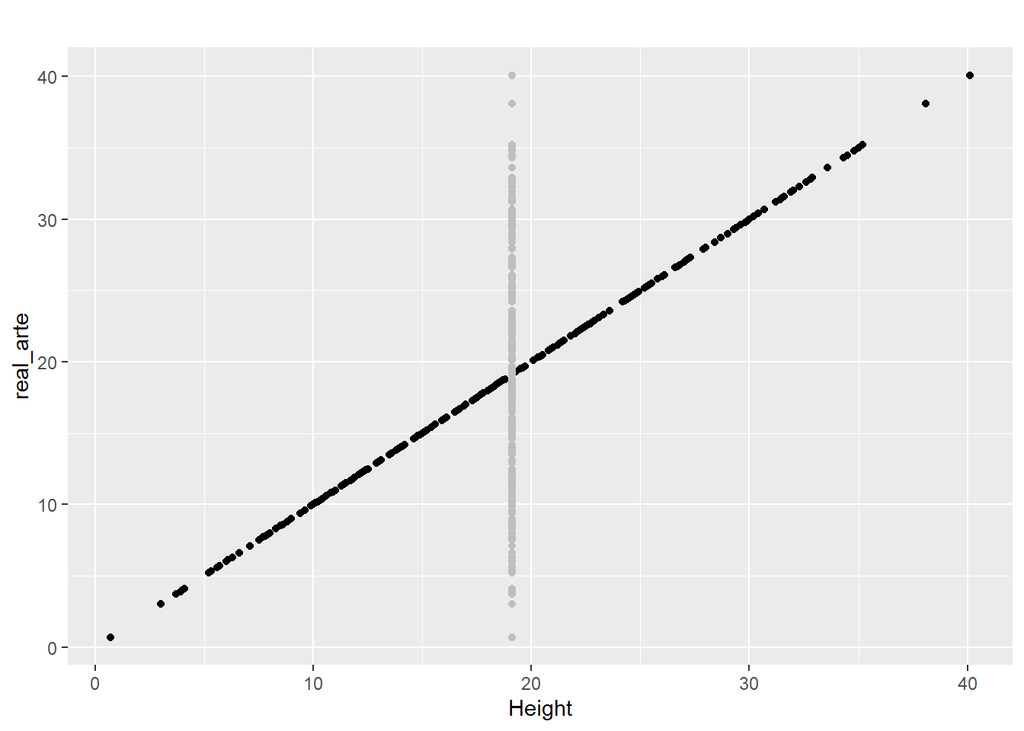

```r
arte <- arte + geom_point(data=meus_desenhos, aes(x=chute_media_Height, y=bodyfat), color = "gray" )
arte
```

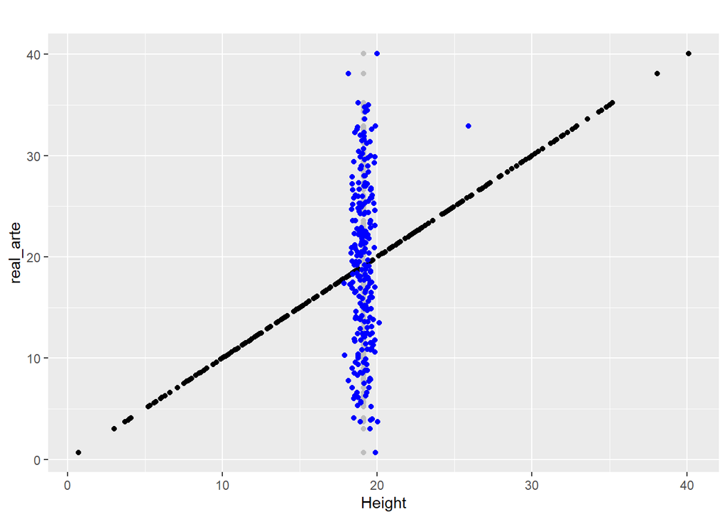

```r
arte <- arte + geom_point(data=meus_desenhos, aes(x=chute_modelo_Height, y=bodyfat), color = "blue" )
arte
```

Análise da Variável Neck

```r
summary(Bodyfat$Neck)
```

```
##    Min. 1st Qu.  Median    Mean 3rd Qu.    Max.
##    31.1    36.4    38.0    38.0    39.4    51.2
```

```r
sd(Bodyfat$Neck)
```

```
## [1] 2.417619
```

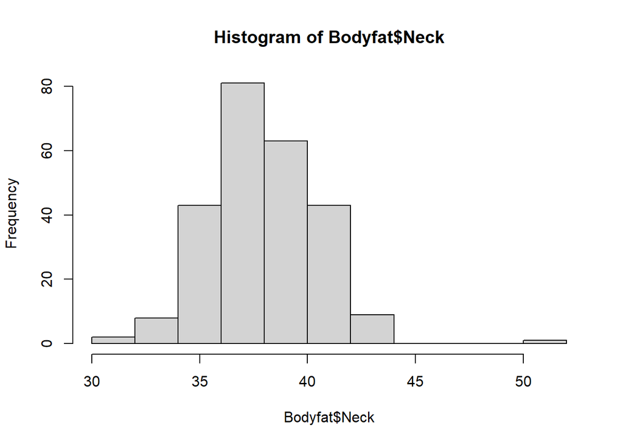

```r
hist(Bodyfat$Neck)
```

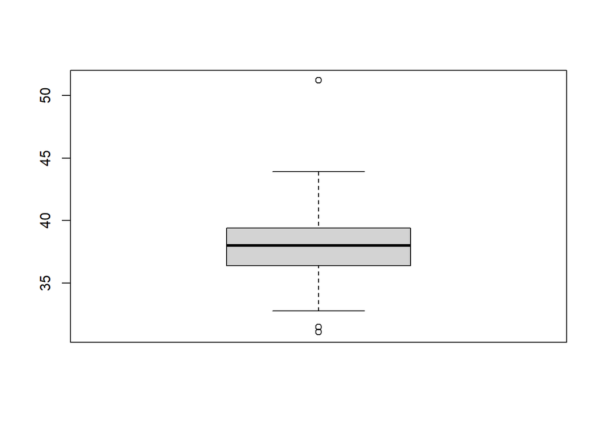

```r
boxplot(Bodyfat$Neck)
```

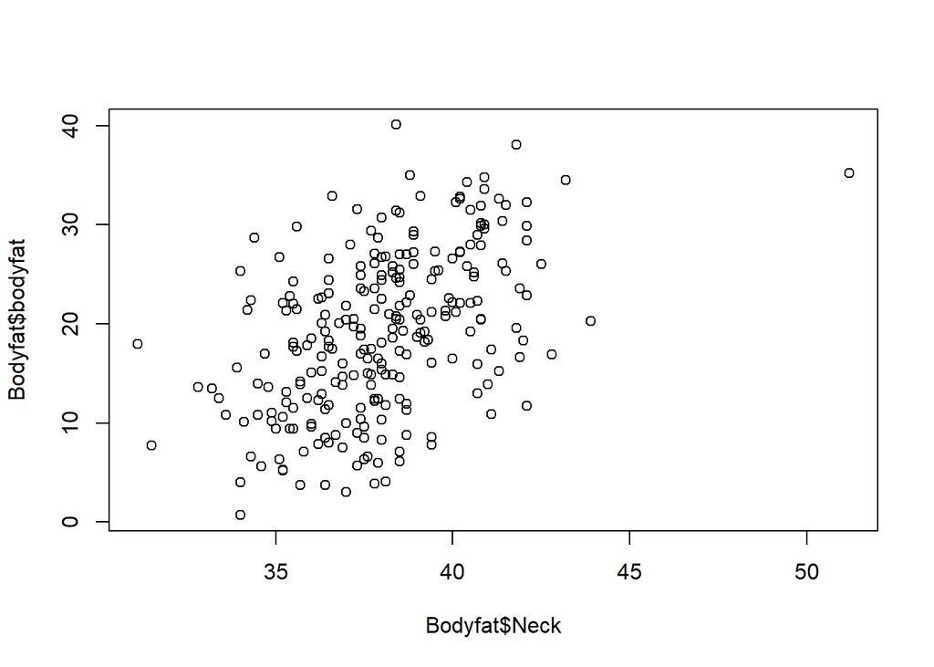

```r
plot(Bodyfat$Neck, Bodyfat$bodyfat)
```

```r
reg_simples_Neck <- lm(bodyfat ~ Neck, data=Bodyfat)
summary(reg_simples_Neck)
```

```
##
## Call:
## lm(formula = bodyfat ~ Neck, data = Bodyfat)
##
## Residuals:
##      Min       1Q   Median       3Q      Max
## -15.1808  -5.1381  -0.1466   5.5708  20.3381
##
## Coefficients:
##             Estimate Std. Error t value Pr(>|t|)
## (Intercept) -41.8180     7.1320  -5.863 1.44e-08 ***
## Neck          1.6036     0.1873   8.561 1.19e-15 ***
## ---
## Signif. codes:  0 '***' 0.001 '**' 0.01 '*' 0.05 '.' 0.1 ' ' 1
##
## Residual standard error: 7.146 on 248 degrees of freedom
## Multiple R-squared:  0.2281, Adjusted R-squared:  0.225
## F-statistic: 73.29 on 1 and 248 DF,  p-value: 1.194e-15
```

```r
#Analisando os outliers
Bodyfat_Neck= Bodyfat[order(Bodyfat$Neck),]
tail(Bodyfat_Neck ,4)
```

```
## # A tibble: 4 × 14
##   bodyfat   Age Weight Height  Neck Chest Abdomen   Hip Thigh  Knee Ankle Biceps
##     <dbl> <dbl>  <dbl>  <dbl> <dbl> <dbl>   <dbl> <dbl> <dbl> <dbl> <dbl>  <dbl>
## 1    16.9    39   106.   1.86  42.8  110.    104.  110.  69.5  43.1  25.8   39.1
## 2    34.5    45   119.   1.72  43.2  128.    126.  126.  72.5  39.6  26.6   36.4
## 3    20.3    35   102.   1.81  43.9  108.    100.  107.  63.3  41.7  24.6   37.2
## 4    35.2    46   165.   1.81  51.2  136.    148.  148.  87.3  49.1  29.6   45
## # … with 2 more variables: Forearm <dbl>, Wrist <dbl>
```

```r
# Realiza o teste
testeShapiro_Neck<- shapiro.test(Bodyfat$Neck)

# Exibe teste
testeShapiro_Neck
```

```
##
##  Shapiro-Wilk normality test
##
## data:  Bodyfat$Neck
## W = 0.96996, p-value = 4.002e-05
```

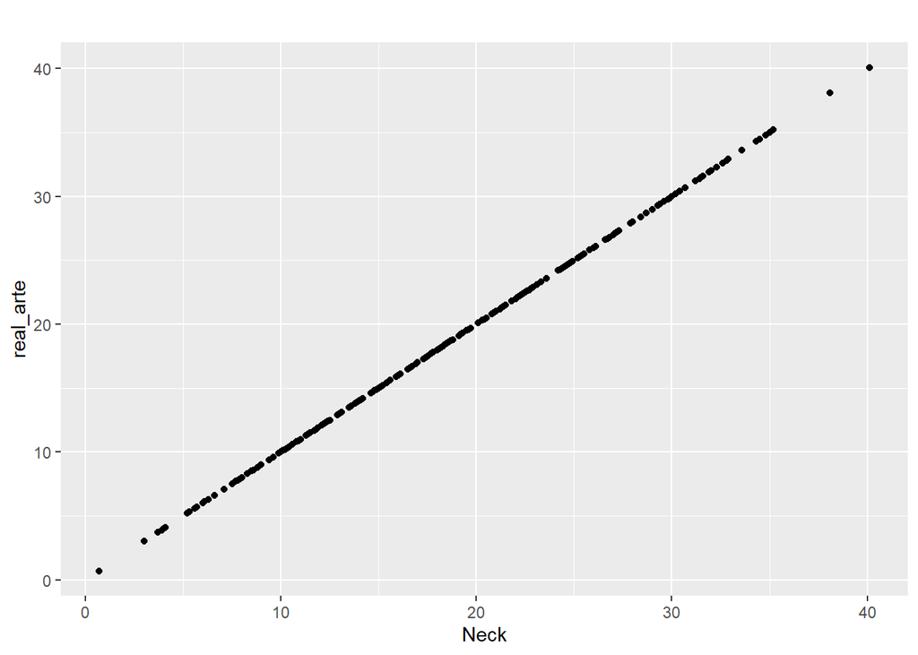

```r
meus_desenhos <- Bodyfat %>% mutate(chute_media_Neck = mean(Bodyfat$bodyfat),chute_modelo_Neck = reg_simples_Neck$fitted.values)

arte <- ggplot()
arte <- arte + geom_point(data=meus_desenhos, aes(x=bodyfat, y=bodyfat), color = "black" ) +
  labs(title = "",
       x = "Neck",
       y = "real_arte",
       color = "green")
arte
```

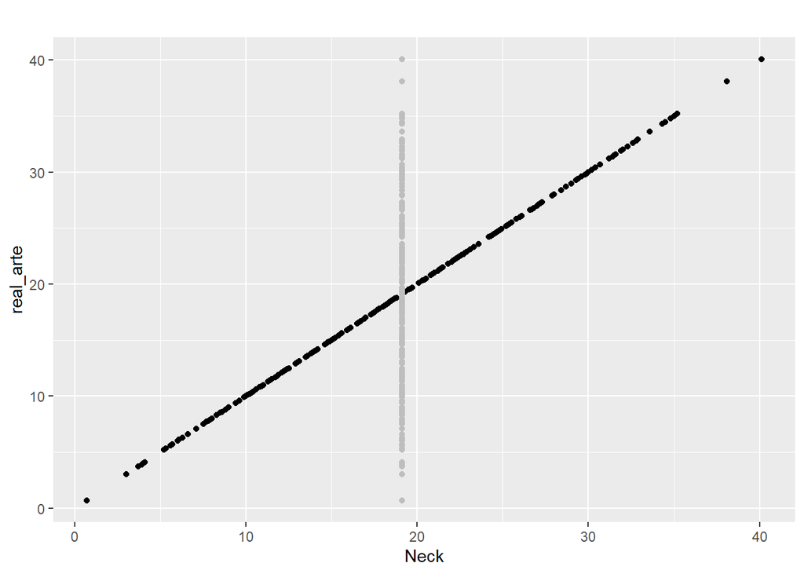

```r
arte <- arte + geom_point(data=meus_desenhos, aes(x=chute_media_Neck, y=bodyfat), color = "gray" )
arte
```

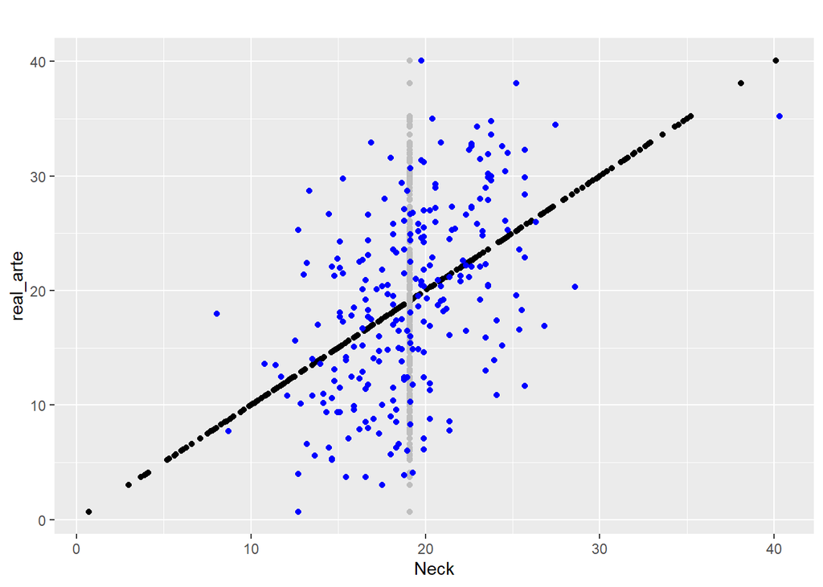

```r
arte <- arte + geom_point(data=meus_desenhos, aes(x=chute_modelo_Neck, y=bodyfat), color = "blue" )
arte
```

Análise da variável Chest

```r
summary(Bodyfat$Chest)
```

```
##    Min. 1st Qu.  Median    Mean 3rd Qu.    Max.
##   83.40   94.45   99.65  100.83  105.30  136.20
```

```r
sd(Bodyfat$Chest)
```

```
## [1] 8.266617
```

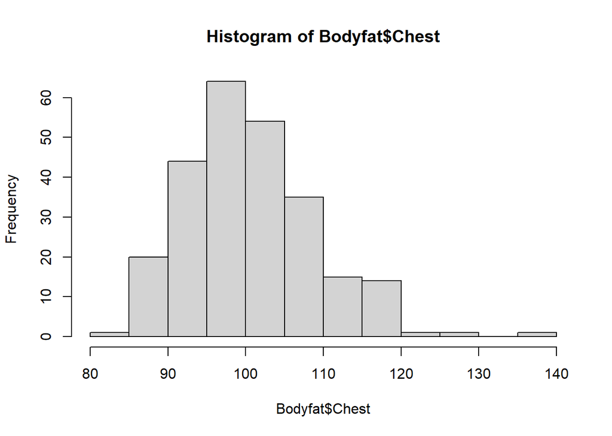

```r
hist(Bodyfat$Chest)
```

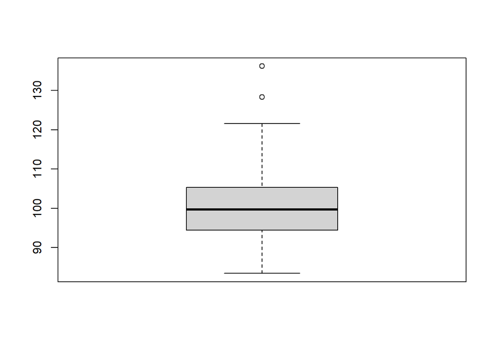

```r
boxplot(Bodyfat$Chest)
```

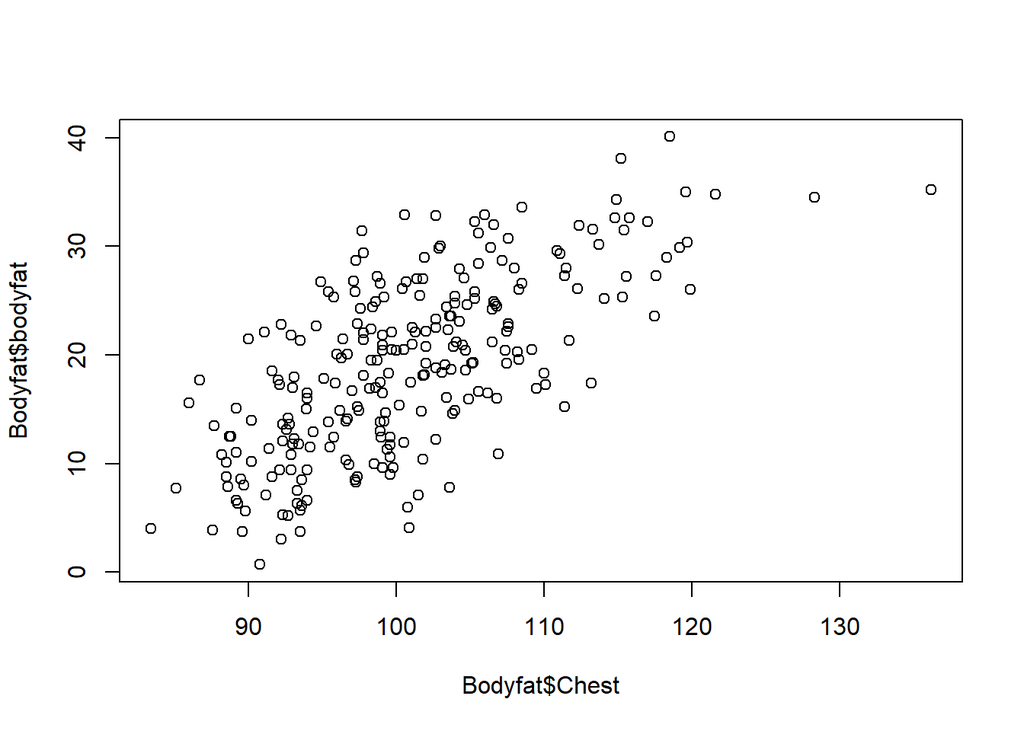

```r
plot(Bodyfat$Chest, Bodyfat$bodyfat)
```

```r
reg_simples_Chest <- lm(bodyfat ~ Chest, data=Bodyfat)
summary(reg_simples_Chest)
```

```
##
## Call:
## lm(formula = bodyfat ~ Chest, data = Bodyfat)
##
## Residuals:
##     Min      1Q  Median      3Q     Max
## -15.058  -4.102  -0.346   3.827  14.403
##
## Coefficients:
##              Estimate Std. Error t value Pr(>|t|)
## (Intercept) -48.98877    4.57952  -10.70   <2e-16 ***
## Chest         0.67539    0.04527   14.92   <2e-16 ***
## ---
## Signif. codes:  0 '***' 0.001 '**' 0.01 '*' 0.05 '.' 0.1 ' ' 1
##
## Residual standard error: 5.905 on 248 degrees of freedom
## Multiple R-squared:  0.473,  Adjusted R-squared:  0.4709
## F-statistic: 222.6 on 1 and 248 DF,  p-value: < 2.2e-16
```